# Gaming Info

Kenny Nguyen, Peter Miyoshi, Ryan McGhee

2/24/2020

## Domain/Data

We are interested in gaming as a domain because it explores a realm of technology that has gained traction and popularity over time, producing complex and interesting advancements in elements such as gaming platforms, companies, and technological innovations (VR, mobile, etc.) Our group has played different video games throughout our lives and it would be interesting to see how our perspective of its evolution parallels trends we uncover. Our merged dataset, sourced [here](https://www.kaggle.com/jummyegg/rawg-game-dataset/data) from Trung Hoang and [here](https://www.kaggle.com/ashaheedq/video-games-sales-2019) from Abdulshaheed Alqunber contains information about many games both old and recent! Both authors published their data through Kaggle.

## Summary Table

Here is a summary of our merged data, grouped by genre and sorted by the total games shipped decending.

| Genre | Total Games | Average Rating (of 100) | Total Shipped (Millions) | Average Playtime (Hours) | Average Number of Achievements |
| --- | --- | --- | --- | --- | --- |
| Role-Playing | 4551 | 76.17797 | 640.79 | 4.674045 | 27.06163 |
| Platform | 3445 | 77.66667 | 575.43 | 1.523138 | 22.02027 |
| Misc | 9476 | 71.56285 | 307.65 | 1.798511 | 22.40554 |
| Action | 7667 | 73.71077 | 289.30 | 2.038670 | 28.58299 |
| Shooter | 4586 | 74.70388 | 289.11 | 2.133575 | 32.67187 |
| Racing | 3030 | 73.80952 | 258.93 | 1.796797 | 22.64274 |
| Sports | 5244 | 75.20000 | 235.90 | 3.403569 | 20.18360 |
| Adventure | 5293 | 74.64943 | 159.65 | 2.551398 | 22.01677 |
| Simulation | 2737 | 74.46961 | 150.29 | 2.489123 | 16.22035 |
| Fighting | 2085 | 76.81818 | 148.65 | 1.765849 | 19.65031 |
| Strategy | 3266 | 74.63686 | 112.31 | 2.086226 | 17.51064 |
| Puzzle | 3162 | 76.50276 | 110.33 | 1.059754 | 26.53251 |
| Action-Adventure | 609 | 74.94706 | 80.36 | 4.898585 | 69.18160 |
| Party | 75 | 72.83333 | 46.96 | 1.333333 | 33.40351 |
| MMO | 74 | 80.57143 | 27.70 | 5.372549 | 44.96078 |
| Music | 195 | 80.76923 | 9.36 | 1.341270 | 79.33333 |
| Visual Novel | 260 | 66.75000 | 3.55 | 3.057471 | 80.72414 |
| Sandbox | 9 | 72.00000 | 1.42 | 7.000000 | 87.22222 |
| Education | 12 | NaN | 0.33 | 2.666667 | 8.00000 |
| Board Game | 16 | NaN | 0.00 | 1.076923 | 19.53846 |

The data was grouped in this way in order to help reveal what genres have been most successful over the years, and includes several different columns which could be used as measures of success, as well as a couple of columns we felt may contain interesting differences between the genres. Looking at the chart you can see that Role-Playing and Platform games are quite popular going by how many were shipped; Both being nearly twice the next highest genre. It is also clear from the chart that Average Playtime is unlikely to be an interesting column to investigate further, at least by genre. The averages are too low to show any major differences. Similarly, ratings between genres don’t show huge differences between them, although between the lowest and highest there might be enough of a difference to be interesting. Finally, achievements might be an interesting category to look into further, as there is a wide range of different values between the genres. These could be due to outliers skewing the results, or perhaps there is actually a connection between genre and number of achievements.

## Chart 1: Kenny

This chart was intended to show the relationship between **playtime** (the hours needed to complete a game) and **critic score** to find out whether one’s engagement with a game is significant to how those games are rated. For critic score, our merged dataset gives us the choice between using the *critic_score* values from Alqunber or the *metacritic* ratings from Hoang. We opted to use *metacritic* because it shows aggregate review scores on a more nuanced scale (*0-100* compared to *1-10*).

[figure not shown]

A scatter plot was used because:

- Playtime and metacritic score are continuous values which can have large amounts of variability.
- A non-linear regression could be plotted on top of points to show the general relationship between playtime vs. critic score.

The axes were also adjusted to remove outliers such as individual games with long playtime or trends with wide confidence intervals i.e. games with critic scores below 40. In this chart, we can see that **higher metacritic ratings are correlated with longer playtime**. This may inform developers that adding elements to a game which increases playtime through replayability or bonus content may be worthwhile during game development.

## Chart 2: Peter

This chart was intended to show the relationship between the Genre of a game and the total number of units it shipped. Unlike the information provided in the summary table, this chart helps to provide a look at the data that makes up those aggregate numbers. A boxplot was chosen to facilitate easy observation of the data that makes up the different categories.

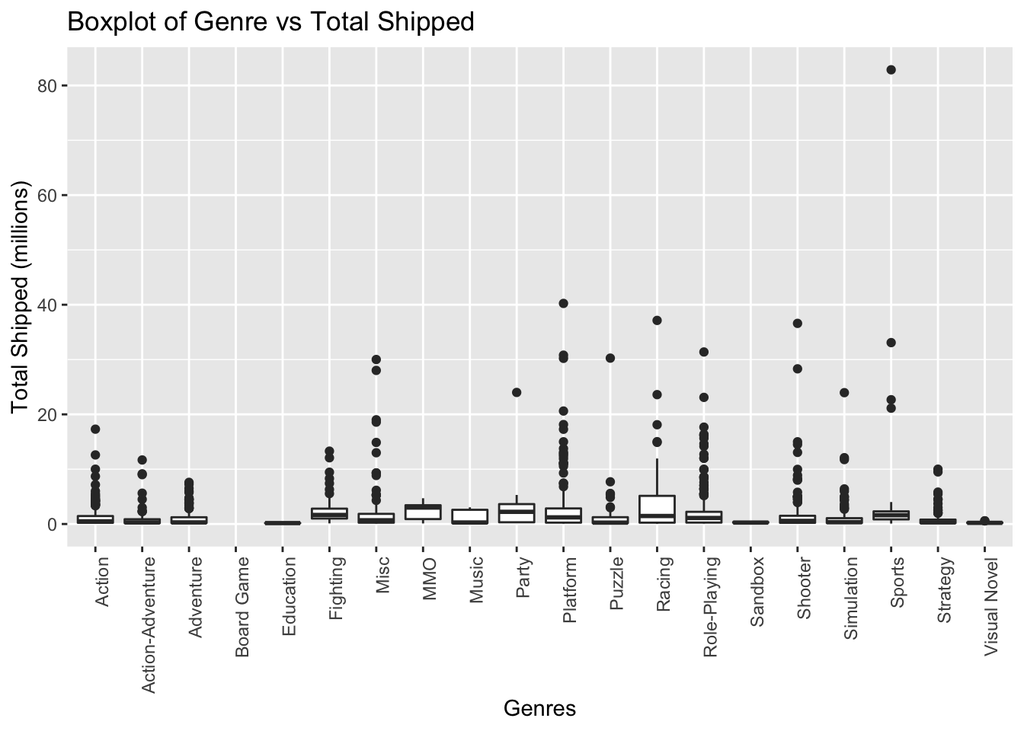

Through this chart you can observe that for the most part, the middle 50% of titles between genres do not show many differences in terms of total shipped. However, certain genres, especially racing, have a larger range for their middle 50%. This suggests that those genres are perhaps more sure bets for success, or have consistent customers who shop specifically for those genres. Several other genres, like Role-Playing, Action, and Shooter games, have quite a few outliers, some with quite large numbers shipped. This suggests that those genres may be more likely to produce smash hits that get many shipped units, despite the averages for those genres being relatively low.

## Chart 3: Ryan

This chart is intended to show the shifting focus of the game industry over time by linking the genre of a game with its release date. This can show which types of games the market is saturated in so that a developer’s game does not get lost in the crowd. This chart can also provide insights for which direction the market is heading.

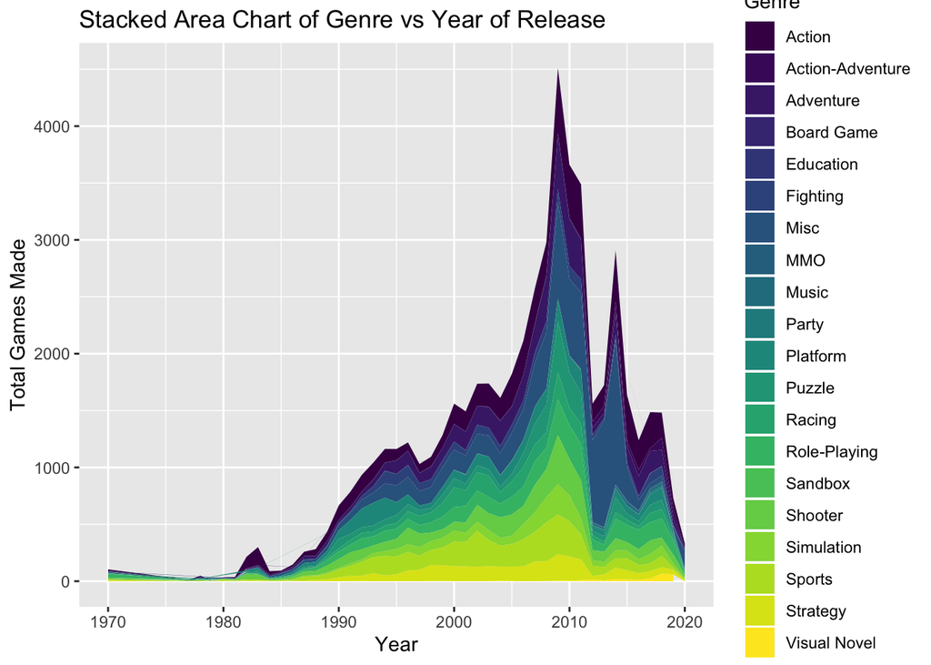

A stacked area chart excels in showing the proportion of games in each individual genre vs the entire market of games.